# Сегментация стран мира по демографическим паттернам (1960-2016)

Data Analysis Portfolio

2026

## О задаче

Бизнес-контекст: Демографические переходы — ключевой индикатор экономического и социального развития стран. Понимание траекторий развития позволяет правительствам и международным организациям прогнозировать потребности в инфраструктуре, здравоохранении и образовании.

Данные: Три датасета Всемирного Банка за период 1960–2016 гг.: - country_population.csv — численность населения - fertility_rate.csv — коэффициент фертильности (среднее число детей на женщину) - life_expectancy.csv — ожидаемая продолжительность жизни при рождении

```r
#install.packages(c("tidyverse", "factoextra", "plotly", "fmsb", "gganimate", "MASS", "broom", "cluster", "patchwork", "kableExtra"));
library(tidyverse); library(ggplot2); library(factoextra); library(plotly); library(tidyr); library(fmsb); library(cluster); library(gganimate); library(MASS); library(broom); library(patchwork); library(kableExtra); if (!dir.exists("output")) dir.create("output"); if (!dir.exists("data")) dir.create("data"); set.seed(123);
```

## 1. Загрузка и предобработка данных

### 1.1. Загрузка трёх датасетов

> Примечание: датасеты не включены в репозиторий. Скачайте country_population.csv, fertility_rate.csv и life_expectancy.csv и поместите в папку data/.

```r
required_files <- c("data/country_population.csv", "data/fertility_rate.csv", "data/life_expectancy.csv");
for (f in required_files) { if (!file.exists(f)) { stop(paste("Файл", f, "не найден. Поместите датасеты в папку data/")) } };
population <- read.csv("data/country_population.csv", stringsAsFactors = FALSE, check.names = FALSE);
fertility <- read.csv("data/fertility_rate.csv", stringsAsFactors = FALSE, check.names = FALSE);
life_exp <- read.csv("data/life_expectancy.csv", stringsAsFactors = FALSE, check.names = FALSE);
```

### 1.2. Преобразование в длинный формат

```r
library(tidyverse);

convert_to_long <- function(df, indicator_name) {
  year_cols <- grep("^[0-9]{4}$", colnames(df), value = TRUE);
  result <- data.frame(Country = character(), Country_Code = character(), Year = integer(), Indicator = character(), Value = numeric(), stringsAsFactors = FALSE);
  for (y in year_cols) {
    tmp <- data.frame(Country = df[["Country Name"]], Country_Code = df[["Country Code"]], Year = as.integer(y), Indicator = indicator_name, Value = df[[y]], stringsAsFactors = FALSE);
    result <- rbind(result, tmp);
  }
  return(result);
};

population_long <- convert_to_long(population, "Population");
life_exp_long <- convert_to_long(life_exp, "Life_Expectancy");
fertility_long <- convert_to_long(fertility, "Fertility");
combined_data <- bind_rows(population_long, life_exp_long, fertility_long);
data <- combined_data %>% pivot_wider(id_cols = c(Country, Country_Code, Year), names_from = Indicator, values_from = Value);
```

### 1.3. Очистка данных

Удаляем страны с высоким процентом пропусков.

```r
na_by_country <- data %>% group_by(Country) %>% summarise(missing_years = sum(is.na(Population) | is.na(Life_Expectancy) | is.na(Fertility)), total_years = n(), na_percent = missing_years / total_years) %>% ungroup(); high_na_countries <- na_by_country %>% filter(na_percent > 0) %>% pull(Country); data_clean <- data %>% filter(!Country %in% high_na_countries) %>% na.omit(); cat("Исходное число наблюдений:", nrow(data), "\n"); cat("После очистки:", nrow(data_clean), "\n"); cat("Число стран:", length(unique(data_clean$Country)), "\n");
```

```
## Исходное число наблюдений: 15048
```

```
## После очистки: 13224
```

```
## Число стран: 232
```

## 2. Разведочный анализ (EDA)

Рассмотрим динамику показателей для 8 репрезентативных стран.

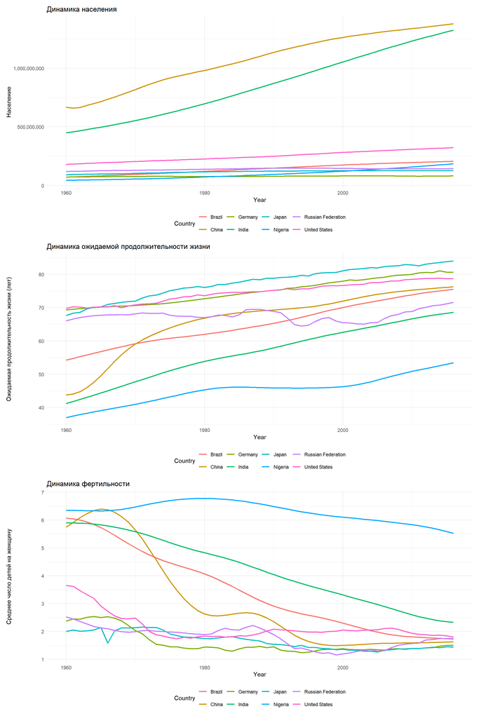

```r
library(patchwork);
representative_countries <- c("United States", "China", "India", "Brazil", "Germany", "Nigeria", "Japan", "Russian Federation");
plot_data <- data_clean %>% filter(Country %in% representative_countries);
p1 <- ggplot(plot_data, aes(x = Year, y = Population, color = Country)) + geom_line(linewidth = 1) + scale_y_continuous(labels = scales::comma) + labs(title = "Динамика населения", y = "Население") + theme_minimal() + theme(legend.position = "bottom");
p2 <- ggplot(plot_data, aes(x = Year, y = Life_Expectancy, color = Country)) + geom_line(linewidth = 1) + labs(title = "Динамика ожидаемой продолжительности жизни", y = "Ожидаемая продолжительность жизни (лет)") + theme_minimal() + theme(legend.position = "bottom");
p3 <- ggplot(plot_data, aes(x = Year, y = Fertility, color = Country)) + geom_line(linewidth = 1) + labs(title = "Динамика фертильности", y = "Среднее число детей на женщину") + theme_minimal() + theme(legend.position = "bottom");
p1 / p2 / p3;
```

**Ключевые паттерны:** - Население: Очень быстрый рост в развивающихся странах (Китай, Индия, Нигерия) - Продолжительность жизни: глобальное сближение показателей с 1960 по 2016 - Фертильность: резкое снижение во всём мире — основной драйвер демографического перехода

## 3. PCA анализ

### 3.1. Подготовка матрицы признаков

Население имеет сильный правосторонний перекос, поэтому применяем логарифмирование.

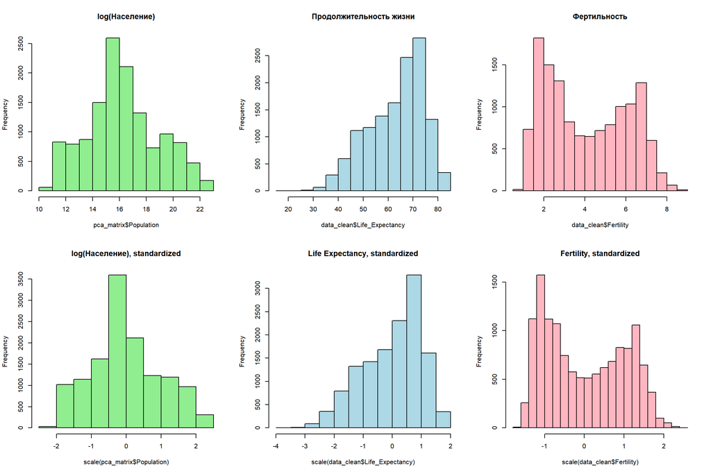

```r
pca_matrix <- data_clean[, c("Population", "Life_Expectancy", "Fertility")];
pca_matrix$Population <- log(pca_matrix$Population);
par(mfrow = c(2, 3));
hist(pca_matrix$Population, main = "log(Население)", col = "lightgreen");
hist(data_clean$Life_Expectancy, main = "Продолжительность жизни", col = "lightblue");
hist(data_clean$Fertility, main = "Фертильность", col = "lightpink");
hist(scale(pca_matrix$Population), main = "log(Население), standardized", col = "lightgreen");
hist(scale(data_clean$Life_Expectancy), main = "Life Expectancy, standardized", col = "lightblue");
hist(scale(data_clean$Fertility), main = "Fertility, standardized", col = "lightpink");
```

```r
pca_scaled <- scale(pca_matrix);
```

### 3.2. Главные компоненты и их интерпретация

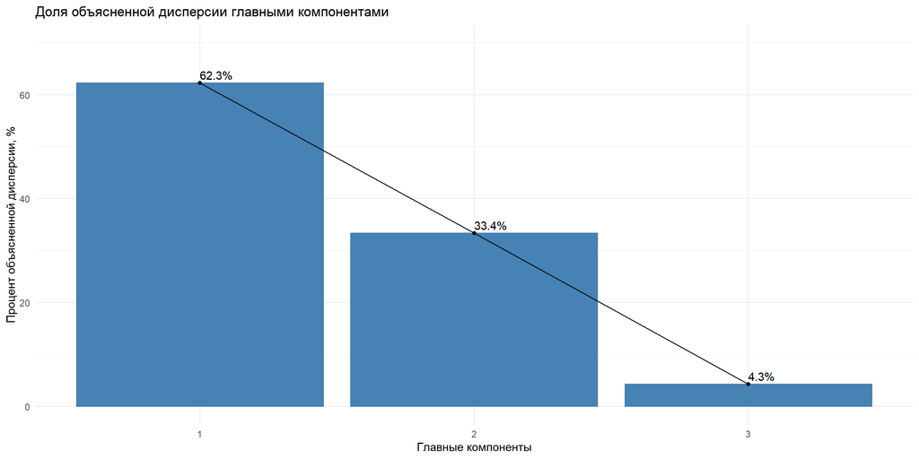

```r
library(factoextra);
pca_result <- prcomp(pca_scaled, center = FALSE);
variance_prop <- pca_result$sdev^2 / sum(pca_result$sdev^2);
fviz_eig(pca_result, addlabels = TRUE, ylim = c(0, 70), barfill = "steelblue", barcolor = "steelblue") + labs(title = "Доля объясненной дисперсии главными компонентами", x = "Главные компоненты", y = "Процент объясненной дисперсии, %") + theme_minimal();
```

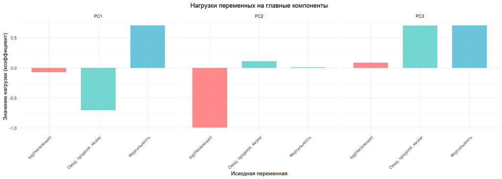

```r
pca_result$rotation %>% as.data.frame() %>% rownames_to_column(var = "Variable") %>% mutate(Variable = case_when(Variable == "Population" ~ "log(Население)", Variable == "Life_Expectancy" ~ "Ожид. продолж. жизни", Variable == "Fertility" ~ "Фертильность", TRUE ~ Variable)) %>% pivot_longer(cols = c(PC1, PC2, PC3), names_to = "Component", values_to = "Loading") %>% ggplot(aes(x = Variable, y = Loading, fill = Variable)) + geom_bar(stat = "identity", alpha = 0.8, width = 0.7) + facet_wrap(~ Component, ncol = 3) + labs(title = "Нагрузки переменных на главные компоненты", y = "Значение нагрузки (коэффициент)", x = "Исходная переменная") + theme_minimal() + theme(axis.text.x = element_text(angle = 45, hjust = 1), legend.position = "none", plot.title = element_text(hjust = 0.5)) + scale_fill_manual(values = c("#FF6B6B", "#4ECDC4", "#45B7D1"));
```

Интерпретация главных компонент:

| Компонента | Доля дисперсии | Смысловая интерпретация |
| --- | --- | --- |
| PC1 | 62.3% | Уровень демографического перехода — высокая продолжительность жизни + низкая фертильность = развитые страны |
| PC2 | 33.4% | Демографический масштаб — размер населения страны |
| PC3 | 4.3% | Специфические паттерны — шум и локальные особенности |

```r
pca_scores <- as.data.frame(pca_result$x);
colnames(pca_scores) <- paste0("PC", 1:ncol(pca_scores));
pca_data <- cbind(data_clean[, c("Country", "Country_Code", "Year")], Population_original = data_clean$Population, Life_Expectancy_original = data_clean$Life_Expectancy, Fertility_original = data_clean$Fertility, log_Population = pca_matrix$Population, pca_scaled, pca_scores);
```

## 4. Кластерный анализ

### 4.1. Определение оптимального числа кластеров

Используем два классических метода: Метод локтя (Elbow) и Метод силуэтов (Silhouette).

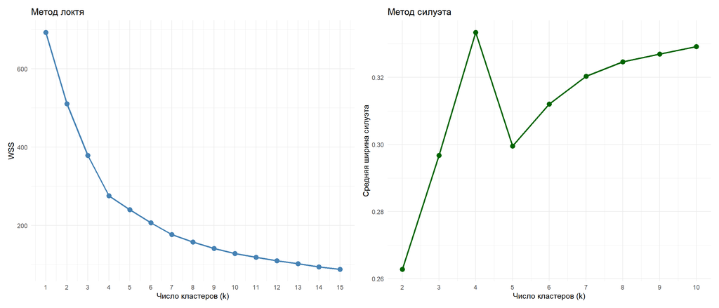

```r
library(cluster);
country_pca_means <- data.frame(Country = data_clean$Country, Year = data_clean$Year, Population = data_clean$Population, Life_Expectancy = data_clean$Life_Expectancy, Fertility = data_clean$Fertility, PC1 = pca_scores[, 1], PC2 = pca_scores[, 2], PC3 = pca_scores[, 3]) %>% group_by(Country) %>% summarise(PC1_mean = mean(PC1, na.rm = TRUE), PC2_mean = mean(PC2, na.rm = TRUE), PC3_mean = mean(PC3, na.rm = TRUE), Population_2016 = last(Population[Year == 2016]), Life_Expectancy_2016 = last(Life_Expectancy[Year == 2016]), Fertility_2016 = last(Fertility[Year == 2016]), n_years = n()) %>% filter(n_years >= 30);
cluster_data <- scale(country_pca_means[, c("PC1_mean", "PC2_mean", "PC3_mean")]);
rownames(cluster_data) <- country_pca_means$Country;
set.seed(59);
wss <- numeric(15);
for (k in 1:15) { kmeans_result <- kmeans(cluster_data, centers = k, nstart = 25, iter.max = 50);
wss[k] <- kmeans_result$tot.withinss };
elbow_df <- data.frame(k = 1:15, wss = wss);
elbow_plot <- ggplot(elbow_df, aes(x = k, y = wss)) + geom_line(color = "steelblue", size = 1) + geom_point(color = "steelblue", size = 3) + scale_x_continuous(breaks = 1:15) + labs(title = "Метод локтя", x = "Число кластеров (k)", y = "WSS") + theme_minimal();
sil_width <- numeric(10);
for (k in 2:10) { kmeans_result <- kmeans(cluster_data, centers = k, nstart = 25);
sil <- silhouette(kmeans_result$cluster, dist(cluster_data));
sil_width[k] <- mean(sil[, 3]) };
sil_df <- data.frame(k = 2:10, sil_width = sil_width[2:10]);
sil_plot <- ggplot(sil_df, aes(x = k, y = sil_width)) + geom_line(color = "darkgreen", size = 1) + geom_point(color = "darkgreen", size = 3) + scale_x_continuous(breaks = 2:10) + labs(title = "Метод силуэта", x = "Число кластеров (k)", y = "Средняя ширина силуэта") + theme_minimal();
elbow_plot | sil_plot;
```

Выбор: k = 4 даёт оптимальный баланс между компактностью кластеров и интерпретируемостью.

### 4.2. K-Means кластеризация (k=4)

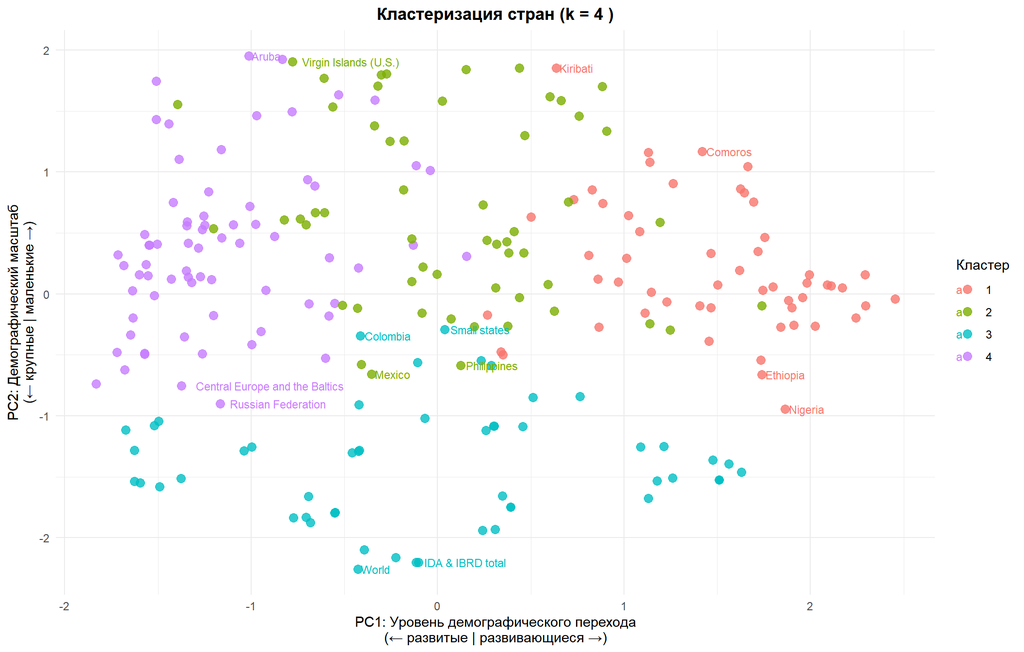

```r
optimal_k <- 4;
kmeans_result <- kmeans(cluster_data, centers = optimal_k, nstart = 25, iter.max = 100);
country_pca_means$Cluster <- as.factor(kmeans_result$cluster);
cluster_plot <- ggplot(country_pca_means, aes(x = PC1_mean, y = PC2_mean, color = Cluster, label = Country)) + geom_point(size = 3, alpha = 0.8) + geom_text(data = country_pca_means %>% group_by(Cluster) %>% slice_max(PC2_mean, n = 2) %>% bind_rows(country_pca_means %>% group_by(Cluster) %>% slice_min(PC2_mean, n = 2)), size = 3, hjust = -0.1, check_overlap = TRUE) + labs(title = paste("Кластеризация стран (k =", optimal_k, ")"), x = "PC1: Уровень демографического перехода\n(← развитые | развивающиеся →)", y = "PC2: Демографический масштаб\n(← крупные | маленькие →)", color = "Кластер") + theme_minimal() + theme(legend.position = "right", plot.title = element_text(hjust = 0.5, face = "bold"));
cluster_plot;
```

```r
ggsave("output/cluster_plot.png", cluster_plot, width = 11, height = 7, dpi = 150);
```

### 4.3. Характеристика кластеров

```r
library(kableExtra);
cluster_characteristics <- country_pca_means %>% group_by(Cluster) %>% summarise(n_countries = n(), PC1_mean = mean(PC1_mean), PC2_mean = mean(PC2_mean), Population_median = median(Population_2016, na.rm = TRUE), Life_Expectancy_mean = mean(Life_Expectancy_2016, na.rm = TRUE), Fertility_mean = mean(Fertility_2016, na.rm = TRUE), Example_Countries = paste(head(Country, 5), collapse = ", ")) %>% mutate(log_Population_z = scale(log(Population_median))[,1], Life_Expectancy_z = scale(Life_Expectancy_mean)[,1], Fertility_z = scale(Fertility_mean)[,1]) %>% arrange(PC1_mean);
display_table <- cluster_characteristics[, c("Cluster", "n_countries", "Life_Expectancy_mean", "Fertility_mean", "Example_Countries")];
display_table$Life_Expectancy_mean <- sprintf("%.1f лет", display_table$Life_Expectancy_mean);
display_table$Fertility_mean <- sprintf("%.2f детей", display_table$Fertility_mean);
tbl <- kable(display_table, caption = "Характеристика кластеров (данные 2016 г.)", col.names = c("Кластер", "N стран", "Продолж. жизни", "Фертильность", "Примеры стран"));
kable_styling(tbl, bootstrap_options = c("striped", "hover"));
```

Характеристика кластеров (данные 2016 г.)

| Кластер | N стран | Продолж. жизни | Фертильность | Примеры стран |
| --- | --- | --- | --- | --- |
| 4 | 70 | 77.6 лет | 1.69 детей | Antigua and Barbuda, Argentina, Armenia, Aruba, Australia |
| 3 | 53 | 71.4 лет | 2.68 детей | Arab World, Bangladesh, Brazil, China, Colombia |
| 2 | 55 | 73.9 лет | 2.65 детей | Albania, Algeria, Bahrain, Belize, Brunei Darussalam |
| 1 | 54 | 62.0 лет | 4.31 детей | Afghanistan, Angola, Benin, Bhutan, Bolivia |

[figure not shown]

```r
profile_long <- data.frame(Cluster = rep(cluster_characteristics$Cluster, 3), Indicator = rep(c("log_Population_z", "Life_Expectancy_z", "Fertility_z"), each = nrow(cluster_characteristics)), Value = c(cluster_characteristics$log_Population_z, cluster_characteristics$Life_Expectancy_z, cluster_characteristics$Fertility_z), stringsAsFactors = FALSE);
profile_plot <- ggplot(profile_long, aes(x = Cluster, y = Value, fill = Indicator)) + geom_bar(stat = "identity", position = "dodge") + labs(title = "Профили кластеров (стандартизированные значения)", x = "Кластер", y = "Z-score") + theme_minimal() + scale_fill_manual(values = c("log_Population_z" = "#4ECDC4", "Life_Expectancy_z" = "#FF6B6B", "Fertility_z" = "#FF02F2"), labels = c("Население", "Продолжительность жизни", "Фертильность"));
profile_plot;
```

```r
ggsave("output/cluster_profiles.png", profile_plot, width = 10, height = 6, dpi = 150);
```

### 4.4. Статистическая валидация (ANOVA)

Проверяем, что кластеры действительно различаются по главным компонентам.

```r
anova_results <- list();
for (var in c("PC1_mean", "PC2_mean", "PC3_mean")) { formula <- as.formula(paste(var, "~ Cluster"));
anova_result <- aov(formula, data = country_pca_means);
anova_results[[var]] <- summary(anova_result);
p_value <- summary(anova_result)[[1]]$"Pr(>F)"[1];
f_value <- summary(anova_result)[[1]]$"F value"[1];
cat(sprintf("%s: F=%.2f, p-value=%.2e\n", var, f_value, p_value));
if (p_value < 0.05) { tukey_result <- TukeyHSD(anova_result);
cat(" Tukey HSD: статистически значимые различия обнаружены\n") } };
```

```
## PC1_mean: F=157.42, p-value=2.77e-55
##  Tukey HSD: статистически значимые различия обнаружены
## PC2_mean: F=118.92, p-value=2.21e-46
##  Tukey HSD: статистически значимые различия обнаружены
## PC3_mean: F=83.68, p-value=1.54e-36
##  Tukey HSD: статистически значимые различия обнаружены
```

## 5. Анализ траекторий (LDA)

Используем Linear Discriminant Analysis для присвоения кластерных меток каждой стране в каждый год. Это позволяет отследить переходы между кластерами.

### 5.1. Обучение LDA модели

```r
library(MASS);
country_pca_means_raw <- country_pca_means[!is.na(country_pca_means$Cluster), c("Country", "PC1_mean", "PC2_mean", "PC3_mean", "Cluster")];
lda_model <- lda(Cluster ~ PC1_mean + PC2_mean + PC3_mean, data = country_pca_means_raw);
cat("Априорные вероятности кластеров:\n");
```

```
## Априорные вероятности кластеров:
```

```r
print(lda_model$prior);
```

```
##         1         2         3         4
## 0.2327586 0.2370690 0.2284483 0.3017241
```

### 5.2. Применение LDA к годовым данным

```r
pca_data_with_clusters <- pca_data[, c("Country", "Year", "PC1", "PC2", "PC3")];
pca_data_with_clusters$Cluster_Year <- predict(lda_model, newdata = data.frame(PC1_mean = pca_data_with_clusters$PC1, PC2_mean = pca_data_with_clusters$PC2, PC3_mean = pca_data_with_clusters$PC3))$class;
country_trajectories <- pca_data_with_clusters %>% group_by(Country) %>% summarise(trajectory = paste(Cluster_Year[order(Year)], collapse = "->"), cluster_1960 = first(Cluster_Year[order(Year)]), cluster_2016 = last(Cluster_Year[order(Year)]), n_years = n(), .groups = "drop") %>% filter(n_years >= 30);
cat("Всего стран с данными >= 30 лет:", nrow(country_trajectories), "\n");
```

```
## Всего стран с данными >= 30 лет: 232
```

### 5.3. Типы переходов

```r
stable_countries <- country_trajectories %>% filter(sapply(strsplit(trajectory, "->"), function(x) length(unique(x)) == 1));
cat("Стабильных стран (не меняли кластер):", nrow(stable_countries), "\n");
```

```
## Стабильных стран (не меняли кластер): 66
```

```r
transition_1_2 <- country_trajectories %>% filter(cluster_1960 == 1, cluster_2016 == 2);
transition_2_4 <- country_trajectories %>% filter(cluster_1960 == 2, cluster_2016 == 4);
transition_1_2_4 <- country_trajectories %>% filter(grepl("1.*2.*4", trajectory));
transitions_summary <- tibble(`Тип перехода` = c("Стабильные", "1 -> 2", "2 -> 4", "1 -> 2 -> 4"), `Количество стран` = c(nrow(stable_countries), nrow(transition_1_2), nrow(transition_2_4), nrow(transition_1_2_4)), `Примеры` = c(paste(head(stable_countries$Country, 3), collapse = ", "), paste(head(transition_1_2$Country, 3), collapse = ", "), paste(head(transition_2_4$Country, 3), collapse = ", "), paste(head(transition_1_2_4$Country, 3), collapse = ", ")));
transitions_summary %>% kable(caption = "Типы демографических переходов (1960-2016)") %>% kable_styling(bootstrap_options = c("striped", "hover"));
```

Типы демографических переходов (1960-2016)

| Тип перехода | Количество стран | Примеры |
| --- | --- | --- |
| Стабильные | 66 | Argentina, Austria, Belarus |
| 1 -> 2 | 30 | Afghanistan, Algeria, Angola |
| 2 -> 4 | 53 | Albania, Antigua and Barbuda, Armenia |
| 1 -> 2 -> 4 | 24 | Algeria, Botswana, Cabo Verde |

## 6. Прогнозирование

### 6.1. Скорость демографического перехода

Линейный тренд PC1 ~ Year позволяет оценить скорость перехода каждой страны.

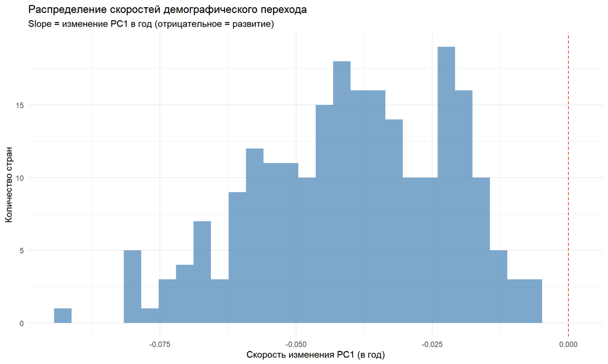

```r
library(broom);
country_trends <- data.frame(Country = character(), slope = numeric(), p_value = numeric(), stringsAsFactors = FALSE);
for (c in unique(pca_data$Country)) {
  country_subset <- pca_data[pca_data$Country == c, ];
  if (nrow(country_subset) > 1) {
    model <- lm(PC1 ~ Year, data = country_subset);
    model_tidy <- tidy(model);
    year_row <- model_tidy[model_tidy$term == "Year", ];
    if (nrow(year_row) > 0) {
      country_trends <- rbind(country_trends, data.frame(Country = c, slope = year_row$estimate, p_value = year_row$p.value, stringsAsFactors = FALSE));
    }
  }
}
speed_plot <- ggplot(country_trends, aes(x = slope)) + geom_histogram(bins = 30, fill = "steelblue", alpha = 0.7) + geom_vline(xintercept = 0, color = "red", linetype = "dashed") + labs(title = "Распределение скоростей демографического перехода", subtitle = "Slope = изменение PC1 в год (отрицательное = развитие)", x = "Скорость изменения PC1 (в год)", y = "Количество стран") + theme_minimal();
speed_plot;
```

```r
ggsave("output/speed_distribution.png", speed_plot, width = 10, height = 6, dpi = 150);
```

### 6.2. Топ-10 стран по скорости перехода

```r
top_slow <- country_trends %>% arrange(desc(slope)) %>% head(10) %>% mutate(slope = sprintf("%.4f", slope));
top_fast <- country_trends %>% arrange(slope) %>% head(10) %>% mutate(slope = sprintf("%.4f", slope));
cat("ТОП-10 стран с самым БЫСТРЫМ демографическим переходом:\n");
```

```
## ТОП-10 стран с самым БЫСТРЫМ демографическим переходом:
```

```r
print(top_fast);
```

```
##               Country   slope      p_value
## 1            Maldives -0.0928 1.008162e-40
## 2             Algeria -0.0814 5.066205e-38
## 3  Iran, Islamic Rep. -0.0814 5.593820e-35
## 4                Oman -0.0809 2.616194e-36
## 5             Tunisia -0.0805 8.667977e-35
## 6              Bhutan -0.0798 2.033638e-41
## 7               Libya -0.0765 3.354471e-41
## 8            Cambodia -0.0745 2.814222e-24
## 9           Nicaragua -0.0722 1.118643e-54
## 10         Bangladesh -0.0721 3.207240e-41
```

```r
cat("\nТОП-10 стран с самым МЕДЛЕННЫМ переходом:\n");
```

```
##
## ТОП-10 стран с самым МЕДЛЕННЫМ переходом:
```

```r
print(top_slow);
```

```
##               Country   slope      p_value
## 1             Ukraine -0.0061 2.690646e-19
## 2  Russian Federation -0.0070 3.333330e-20
## 3              Latvia -0.0079 1.357064e-11
## 4             Belarus -0.0094 1.426989e-35
## 5           Lithuania -0.0102 1.509742e-25
## 6            Bulgaria -0.0107 2.006147e-31
## 7             Estonia -0.0119 1.009280e-17
## 8             Hungary -0.0127 3.962777e-22
## 9             Denmark -0.0130 2.613613e-24
## 10               Chad -0.0131 3.214793e-15
```

### 6.3. Прогноз: когда страны достигнут порога «развитых» (PC1 < 0)

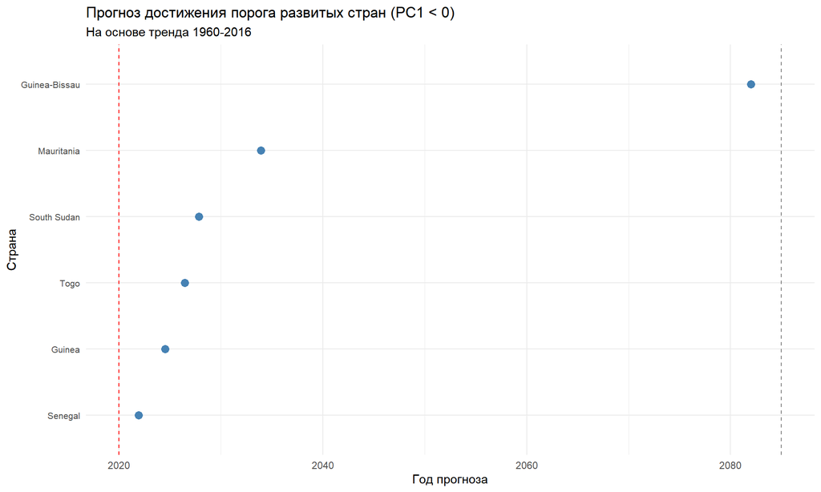

```r
library(minpack.lm)

forecast_threshold <- function(country_name, threshold = 0) {
  d <- pca_data %>% filter(Country == country_name)
  if (nrow(d) < 10) return(NA_real_)

  fit <- try(nlsLM(PC1 ~ SSfpl(Year, A, B, xmid, scal), data = d), silent = TRUE)
  if (inherits(fit, "try-error")) return(NA_real_)

  f <- function(t) predict(fit, newdata = data.frame(Year = t)) - threshold
  if (f(2017) * f(2216) > 0) return(NA_real_)      # порог недостижим (за асимптотой)
  uniroot(f, c(2017, 2216))$root                    # год пересечения
}
forecasts <- country_trends %>% rowwise() %>% mutate(forecast_year = forecast_threshold(Country, threshold = 0)) %>% filter(!is.na(forecast_year), forecast_year > 2020, forecast_year < 2085) %>% arrange(forecast_year);
forecast_plot <- ggplot(forecasts %>% head(20), aes(x = reorder(Country, forecast_year), y = forecast_year)) + geom_point(size = 3, color = "steelblue") + geom_hline(yintercept = 2020, linetype = "dashed", color = "red") + geom_hline(yintercept = 2085, linetype = "dashed", color = "gray50") + coord_flip() + labs(title = "Прогноз достижения порога развитых стран (PC1 < 0)", subtitle = "На основе тренда 1960-2016", x = "Страна", y = "Год прогноза") + theme_minimal() + theme(axis.text.y = element_text(size = 8));
forecast_plot;
```

```r
ggsave("output/forecast.png", forecast_plot, width = 10, height = 8, dpi = 150);
```

## 7. Анимация демографических переходов

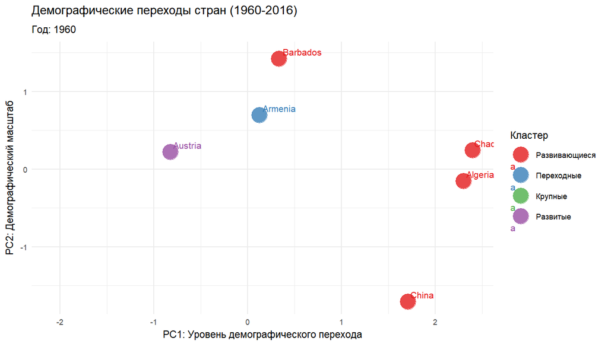

```r
# Анимация требует длительного рендеринга (~10-15 минут)
# Раскомментируйте для локального запуска
library(gganimate);
selected_countries <- c("Chad", "Austria", "Algeria", "Armenia", "Barbados", "China");
anim_data <- pca_data_with_clusters %>% filter(Country %in% selected_countries) %>% mutate(Country = factor(Country, levels = selected_countries), Cluster_Year = as.factor(Cluster_Year));
anim_plot <- ggplot(anim_data, aes(x = PC1, y = PC2, color = Cluster_Year, group = Country)) + geom_point(size = 8, alpha = 0.8) + geom_text(aes(label = Country), hjust = -0.1, vjust = -0.5, size = 3.5, check_overlap = TRUE) + scale_color_manual(values = c("1" = "#E41A1C", "2" = "#377EB8", "3" = "#4DAF4A", "4" = "#984EA3"), labels = c("1" = "Развивающиеся", "2" = "Переходные", "3" = "Крупные", "4" = "Развитые")) + transition_time(Year) + labs(title = "Демографические переходы стран (1960-2016)", subtitle = "Год: {frame_time}", x = "PC1: Уровень демографического перехода", y = "PC2: Демографический масштаб", color = "Кластер") + theme_minimal();
anim_save("output/cluster_transitions.gif", anim_plot, nframes = 114, fps = 10, width = 1400, height = 800, units = "px", res = 150);
knitr::include_graphics("output/cluster_transitions.gif");
```

## Итоговая таблица результатов

| Параметр | Значение |
| --- | --- |
| Период анализа | 1960 – 2016 (57 лет) |
| Число стран с полной динамикой | 232 |
| Доля дисперсии в PC1 | 62.3% |
| Число кластеров | 4 |
| Стран, сменивших кластер | 166 |
| Метод кластеризации | K-Means (k=4) |

## Выводы

1. PCA эффективно выделяет две главные оси развития:
- PC1 (62.3% дисперсии) — уровень демографического перехода
- PC2 — демографический масштаб (размер страны)
2. Три из четыре устойчивых кластера отражают классические стадии демографического перехода:
- Развивающиеся → Переходные → Развитые (+ крупные страны и группы стран как отдельная группа)
3. Большинство стран прошли последовательный путь развития. Лишь немногие сохранили стабильный кластер с 1960 года.
4. Прогноз на основе трендов позволяет оценить, когда развивающиеся страны достигнут показателей развитых — что критически важно для планирования международной помощи и инвестиций.
5. LDA анализ траекторий даёт воспроизводимый способ классифицировать страны по годам, а не только по усреднённым показателям.

## Технологии

R, tidyverse, factoextra, gganimate, MASS, broom, patchwork, kableExtra

## Как запустить

1. Скачайте три датасета с Kaggle или World Bank Data
2. Поместите CSV-файлы в папку data/
3. Откройте analysis.Rmd в RStudio
4. Нажмите Knit (Ctrl+Shift+K)
5. Получите обновлённый analysis.html со всеми графиками

## Автор

**[Вячеслав AKA Zo2uEv7lPR]** - Telegram: @Zo2uEv7lPR - Email: Zo2uEv7lPR@yandex.ru